# A walk-through guide for quantitative characterisation of iridescent colours

Hugo Gruson

Christine Andraud

Willy Daney de Marcillac

Serge Berthier

Marianne Elias

Doris Gomez

Compiled on 2018-09-04

# Preamble

This notebook contains the necessary code and instructions to reproduce our results published in the paper: “Quantitative characterisation of iridescent colours in biological studies: a novel method using optical theory”. This notebook format allows you to conviently browse the final result in your usual web browser. Should you wish to run the code yourself, you code download a rmarkdown (`.Rmd`) file from the notebook.

This code was running fine when this file was last compiled (2018-09-04). It is however possible that in the meantime, some of the packages we use have been updated and it does not work anymore. In this case, please contact us. You can also check the full list and version of the package we used in the `session_info()` at the end of this notebook.

In this example, we focus on the iridescent feathers of the breast of the hummingbird *Heliomaster furcifer* to desmontrate the method. In this specific example, we obtain good results by using angles up to 45° but as stated in the manuscript, it may be necessary to restrict your analysis to angles lower than 30° in some cases. We did not find any significant difference in parameters values when estimated with angles $\leq 30°$ and $\leq 45°$ for hummingbirds and butterflies in our analysis.

This angle use files saved as `.jdx` using an OceanOptics spectrometer but this code can easily be modified to work with any file format, by using the `lightR` package (https://github.com/bisaloo/lightR).

# Measurements

We put the measurements for hue and brightness in two different folders named `Hue` and `Brightness` respectively.

## Measurements for brightness

A explained in this article, brightness is constant as long as the angle bisector of the two optical fibres of the goniometer remains constant ($\Phi_{inc}-\Phi_{col}=cst$). To estimate the variation of brightness in the angle space ($\Phi_{inc},\Phi_{col}$), we thus need to take measurements along the orthogonal axis $\Phi_{inc}+\Phi_{col}=cst$.

1. We move one of the two fibres of the goniometer to find the position where we get a signal of maximal intensity. This position depends on the tilt $t$ of the multilayer and is therefore different for every sample. Once this is done, this means the angle bisector of the two fibres is close to the normal to the multilayer structure. In our case, we get this when the bisector between the fibres is at 18°.
2. We take measurements while keeping the angular span between the two fibres constant (20°) and moving the angle bisector.
3. We name the files according to the following pattern `SPECIES_PATCH_PHIINC_PHICOL`. All files related to brightness estimation are in a folder named `Brightness`. So in our case, we get 9 files named **Brightness/HELIFURC_BR_38_-18.jdx, Brightness/HELIFURC_BR_33_-13.jdx, Brightness/HELIFURC_BR_28_-8.jdx, Brightness/HELIFURC_BR_23_-3.jdx, Brightness/HELIFURC_BR_18_2.jdx, Brightness/HELIFURC_BR_13_7.jdx, Brightness/HELIFURC_BR_8_12.jdx, Brightness/HELIFURC_BR_3_17.jdx, Brightness/HELIFURC_BR_-2_22.jdx**

## Measurements for hue

Conversely, hue is constant when the span between the two fibres is constant. To estimate the variation of hue in the angle space, we therefore perform several measurements with different angular spans but the same angle bisector.

1. We know keep the supposed normal of the multilayer as the fibre angle bisector and change the span, producing 8 files **Hue/HELIFURC_BR_23_-13.jdx, Hue/HELIFURC_BR_28_-8.jdx, Hue/HELIFURC_BR_33_-3.jdx, Hue/HELIFURC_BR_38_2.jdx, Hue/HELIFURC_BR_43_7.jdx, Hue/HELIFURC_BR_48_12.jdx, Hue/HELIFURC_BR_53_17.jdx, Hue/HELIFURC_BR_58_22.jdx**

## White reference measurements

We need to take the same measurements as before but without any tilt, i.e.:

# Pre-processing spectral data

Here is a helper function modified from R package `lightR` (https://github.com/bisaloo/lightR) to output a dataframe with the white reference, the black reference and the raw count data in separate columns (instead of the processed normalised data):

```r
parse_jdx <- function(filename) {
  content <- readLines(filename)

  # According to the standard, all blocks must start and end in this way:
  blockstarts <- grep("^##TITLE=", content)[-1]
  blockends   <- grep("^##END=", content)[-4]

  blocktype <- content[blockstarts]
  blocktype <- tolower(gsub(".+: ([[:alpha:]]+) SPECTRUM$", "\\1", blocktype))

  get_data <- function(index) {
    # Data is contained in lines that do NOT start with ##
    data <- grep("^##", content[blockstarts[index]:blockends[index]],
                 value = TRUE, invert = TRUE)
    data <- strsplit(data, ",")
    data <- do.call(rbind, data)
  }

  scope_data <- get_data(which(blocktype=="processed"))
  dark_data <- get_data(which(blocktype=="dark"))
  white_data <- get_data(which(blocktype=="reference"))

  data <- cbind(scope_data[,1], dark_data[,2], white_data[,2], scope_data[,2])
  colnames(data) <- c("wl", "dark", "white", "scope")
  data <- data.frame(apply(data, 2, as.numeric))
  data$processed <- (data$scope - data$dark) / (data$white - data$dark) * 100

  return(data)

}
```

Let us pre-process the spectra for brightness parameters estimation first:

```r
# List of files that DO NOT start with "W"
specfiles = list.files(path = "Brightness", pattern = "^[^W].*\\.jdx", full.names = TRUE, recursive = TRUE)

file_norms =  (sapply(strsplit(specfiles, "[[:punct:]]"), function(x) as.numeric(x[[length(x)-1]])) -
                 sapply(strsplit(specfiles, "[[:punct:]]"), function(x) as.numeric(x[[length(x)-2]]))) / 2
file_species = sapply(strsplit(specfiles, "[/_\\.-]"), function(x) x[[2]])
by(file_norms, file_species, order)
```

```
file_species: Heliomaster furcifer
[1] 9 8 7 6 5 4 3 2 1
```

```r
preprocess_norms = function(file) {

  file_infos = strsplit(file, "[/_\\.-]")[[1]]

  norms = (as.numeric(file_infos[length(file_infos)-1]) -
    as.numeric(file_infos[length(file_infos)-2])) / 2
  species = file_infos[2]

  whitefiles = list.files(path = paste("Brightness", species, sep = "/"),
                          pattern = "^WHITE", full.names = TRUE)
  white_norms = (sapply(strsplit(whitefiles, "[[:punct:]]"), function(x) as.numeric(x[[length(x)-1]])) -
                   sapply(strsplit(whitefiles, "[[:punct:]]"), function(x) as.numeric(x[[length(x)-2]]))) / 2

  specdf = parse_jdx(file)

  whitedf = parse_jdx(whitefiles[which(file_norms[file_species == species]==norms)])

  cor = (specdf$scope - specdf$dark) /
        (whitedf$scope - whitedf$dark) * 100

  res = data.frame(wl = specdf$wl, cor)

  write.csv(res, gsub("\\.jdx$", ".csv", file),
            row.names = FALSE)
}

sapply(specfiles, preprocess_norms)
```

```
$`Brightness/Heliomaster furcifer/HELIFURC_BR_278_282.jdx`
NULL

$`Brightness/Heliomaster furcifer/HELIFURC_BR_283_277.jdx`
NULL

$`Brightness/Heliomaster furcifer/HELIFURC_BR_288_272.jdx`
NULL

$`Brightness/Heliomaster furcifer/HELIFURC_BR_293_267.jdx`
NULL

$`Brightness/Heliomaster furcifer/HELIFURC_BR_298_262.jdx`
NULL

$`Brightness/Heliomaster furcifer/HELIFURC_BR_303_257.jdx`
NULL

$`Brightness/Heliomaster furcifer/HELIFURC_BR_308_252.jdx`
NULL

$`Brightness/Heliomaster furcifer/HELIFURC_BR_313_247.jdx`
NULL

$`Brightness/Heliomaster furcifer/HELIFURC_BR_318_242.jdx`
NULL
```

We do the same for files used in estimation of hue parameters

```r
specfiles = list.files(path = "Hue", pattern = "^[^W].*\\.jdx", full.names = TRUE, recursive = TRUE)

preprocess_span = function(file) {

  # Match all punct but spaces
  file_infos = strsplit(file, "[/_\\.-]")[[1]]
  span = as.numeric(file_infos[length(file_infos)-1]) +
         as.numeric(file_infos[length(file_infos)-2]) + 180 - 720
  species = file_infos[2]

  whitefiles = list.files(path = paste("Hue", species, sep = "/"),
                          pattern = "^WHITE", full.names = TRUE)
  white_spans = sapply(strsplit(whitefiles, "[[:punct:]]"), function(x) as.numeric(x[[length(x)-1]])) +
    sapply(strsplit(whitefiles, "[[:punct:]]"), function(x) as.numeric(x[[length(x)-2]])) +
    180 - 720

  specdf = parse_jdx(file)

  whitedf = parse_jdx(whitefiles[white_spans == span])

  cor = (specdf$scope - specdf$dark) /
        (whitedf$scope - whitedf$dark) * 100

  res = data.frame(wl = specdf$wl, cor)

  write.csv(res, gsub("\\.jdx$", ".csv", file),
            row.names = FALSE)

}

sapply(specfiles, preprocess_span)
```

```
$`Hue/Heliomaster furcifer/HELIFURC_BR_297_253.jdx`
NULL

$`Hue/Heliomaster furcifer/HELIFURC_BR_302_258.jdx`
NULL

$`Hue/Heliomaster furcifer/HELIFURC_BR_307_263.jdx`
NULL

$`Hue/Heliomaster furcifer/HELIFURC_BR_312_268.jdx`
NULL

$`Hue/Heliomaster furcifer/HELIFURC_BR_317_273.jdx`
NULL

$`Hue/Heliomaster furcifer/HELIFURC_BR_322_278.jdx`
NULL

$`Hue/Heliomaster furcifer/HELIFURC_BR_327_283.jdx`
NULL

$`Hue/Heliomaster furcifer/HELIFURC_BR_332_288.jdx`
NULL
```

# Iridescence parameters estimation

```r
library(pavo)
library(tidyverse)
theme_set(theme_minimal())
```

This function extracts the colour variables we are going to use ($H_1$ for hue and $B_2$ for brightness).

```r
get_colvar_folder = function(folder_path, wlim = c(300,700)) {

  spectra_folder = suppressWarnings(getspec(folder_path, sep = ",", ext = "csv",
                           subdir = TRUE, subdir.names = FALSE, lim = wlim))

  spectra_folder = procspec(spectra_folder, opt = "smooth", fixneg = "zero")

  colvar_folder = summary(spectra_folder, subset = c("H1", "B2"))
  colvar_folder$I = sapply(strsplit(rownames(colvar_folder), "_"), function(x) x[length(x)-1])
  colvar_folder$C = sapply(strsplit(rownames(colvar_folder), "_"), function(x) x[length(x)])
  colvar_folder$span = 180 + as.numeric(colvar_folder$I) + as.numeric(colvar_folder$C) - 720
  colvar_folder$halfspan = colvar_folder$span / 2
  colvar_folder$normale = (as.numeric(colvar_folder$I) - as.numeric(colvar_folder$C)) / 2

  # Hue for black patches is NA
  colvar_folder[colvar_folder$B2<8.5, "H1"] = NA

  # Remove artefact at the edges
  colvar_folder$H1[colvar_folder$H1 %in% c(300,700)] = NA

  # Discard large angles
  colvar_folder = colvar_folder[colvar_folder$span<90,]


  return(colvar_folder)
}
```

`pavo` works with base graphics. If we want to plot spectra using `ggplot2`, we have to define our own function:

```r
ggplot_rspec = function(x) {

  rspecdata = as.rspec(x)
  rspecdata_long = tidyr::gather(rspecdata, name, spec, -wl)

  g = ggplot(data = rspecdata_long,
             aes(x = wl, y = spec, group = name, col = name)) +
    geom_line() +
    ylab("Reflectance (%)") +
    xlab("Wavelength") +
    scale_colour_manual(values = spec2rgb(rspecdata))
  return(g)
}
```

Let’s start by having a look a the spectra before estimating any parameters values:

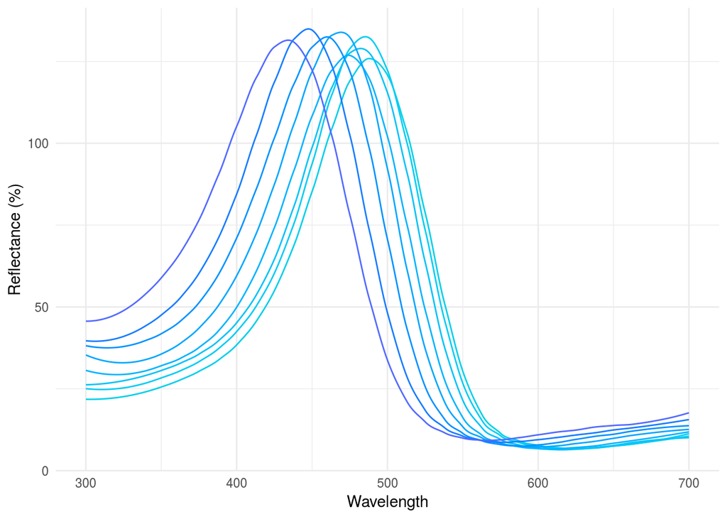

```r
helfur_br_h = getspec("Hue", sep = ",", ext = "csv", subdir = TRUE)
helfur_br_h = procspec(helfur_br_h, "smooth", "zero")
ggplot_rspec(helfur_br_h) + theme(legend.position = "none")
```

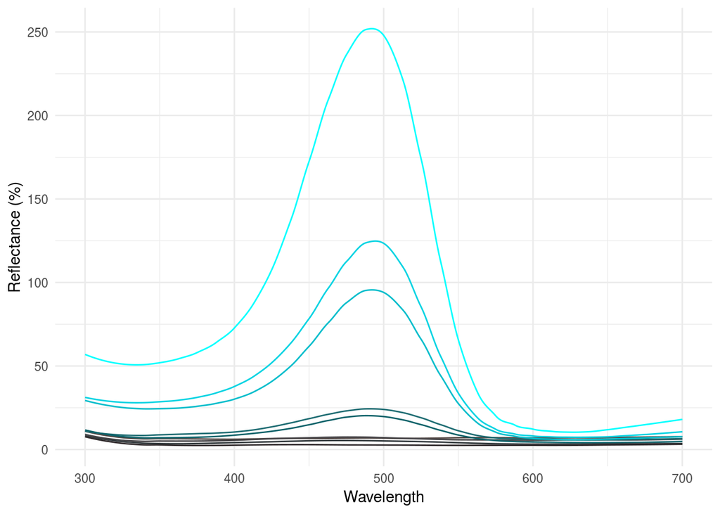

```r
helfur_br_b = getspec("Brightness", sep = ",", ext = "csv", subdir = TRUE)
helfur_br_b = procspec(helfur_br_b, "smooth", "zero")
ggplot_rspec(helfur_br_b) + theme(legend.position = "none")
```

Get the values of hue and brightness

```r
helfur_br_hvar = get_colvar_folder("Hue")
helfur_br_hvar$rgb = spec2rgb(helfur_br_h)
helfur_br_bvar = get_colvar_folder("Brightness")
helfur_br_bvar$rgb = spec2rgb(helfur_br_b)
```

We first define the simple normal and cos functions that will be used for brightness and hue.

```r
fnorm = function(x, Bmax, t, gammaB) {
  Bmax * exp(-0.5*(x-t)^2/gammaB^2)
}
fcos = function(x, Hmax, gammaH) {
  Hmax * cos(gammaH * x / 180 * pi)
}
```

We then define the functions that find the sets of parameters for brightness and hue optimized in non linear least square method.

```r
find_params_nls_normale = function(brightness_folder) {

  maxi = max(brightness_folder$B2)
  norm = brightness_folder$normale[which.max(brightness_folder$B2)]
  sigm = abs(brightness_folder$normale[which.min(abs(brightness_folder$B2 - exp(-0.5) * maxi))] - norm)

  fit = nls(B2 ~ fnorm(normale, Bmax, t, gammaB),
      data = brightness_folder,
      start = c("Bmax"=maxi, "t"=norm, "gammaB"=sigm),
      lower = c("Bmax"=0   , "t"=-50 , "gammaB"=0),
      algorithm = "port",
      nls.control(warnOnly = TRUE))

  return(summary(fit)$coefficients[,1])
}

find_params_nls_span = function(hue_folder) {

  hue_folder = hue_folder[!is.na(hue_folder$H1),]

  if (nrow(hue_folder)<2) {
    # If only one measurement, we can't estimate parameters

    return(rep(NA,2))

  } else {

    maxi = max(hue_folder$H1)
    s = 0.6

    fit = nls(H1 ~ fcos(halfspan, Hmax, gammaH),
              data = hue_folder,
              start = c("Hmax"=maxi, "gammaH"=s),
              control = nls.control(warnOnly = TRUE))

    return(summary(fit)$coefficients[,1])

  }
}
```

We then perform nonlinear least square optimization on our example.

```r
helfur_br_bregres = find_params_nls_normale(helfur_br_bvar)
helfur_br_hregres = find_params_nls_span(helfur_br_hvar)
```

We further plot the results, along with the estimated parameter values

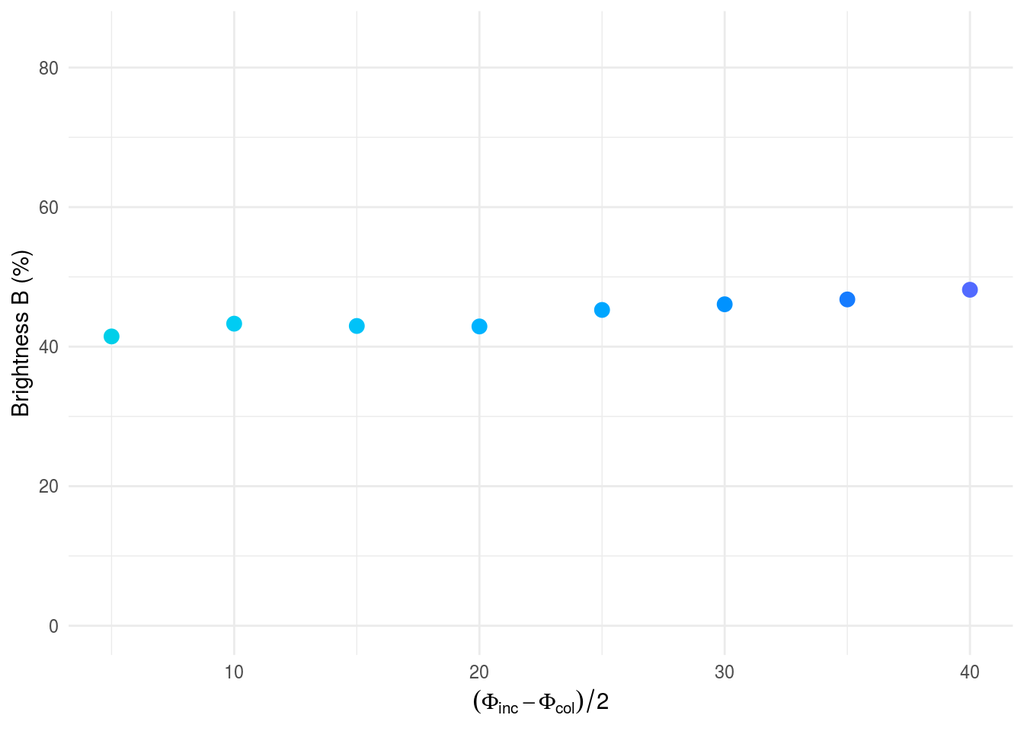

```r
ggplot(helfur_br_hvar, aes(x = halfspan, y = B2, col = factor(halfspan))) +
  geom_point(size = 3) +
  xlab(expression((Phi[inc]-Phi[col])/2)) +
  ylim(c(0, max(helfur_br_bvar$B2, helfur_br_hvar$B2))) +
  ylab("Brightness B (%)") +
  scale_color_manual(values = unname(spec2rgb(helfur_br_h))) +
  theme(legend.position = "none")
```

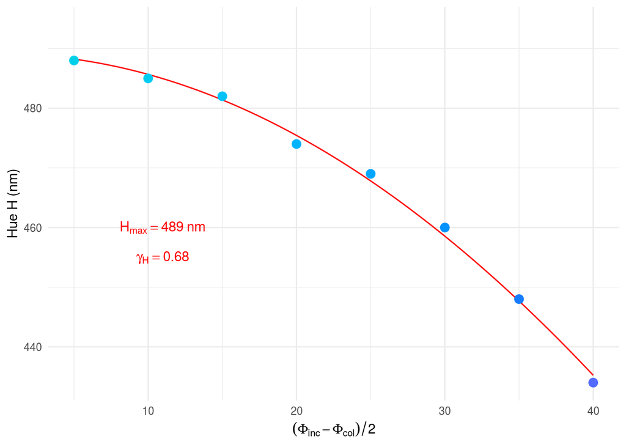

```r
ggplot(helfur_br_hvar, aes(x = halfspan, y = H1, col = factor(halfspan))) +
  xlab(expression((Phi[inc]-Phi[col])/2)) +
  stat_function(fun = fcos, args = helfur_br_hregres, color = "red") +
  geom_point(size = 3) +
  ylim(range(helfur_br_bvar$H1, helfur_br_hvar$H1, na.rm = TRUE)) +
  ylab("Hue H (nm)") +
  scale_color_manual(values = unname(spec2rgb(helfur_br_h))) +
  theme(legend.position = "none") +
  annotate("text", x = 11, y = 460, color = "red",
           label = sprintf("H[max]== %.0f~nm", helfur_br_hregres[["Hmax"]]), parse = TRUE) +
  annotate("text", x = 11, y = 455, color = "red",
           label = sprintf("gamma[H]== %.2f", helfur_br_hregres[["gammaH"]]), parse = TRUE)
```

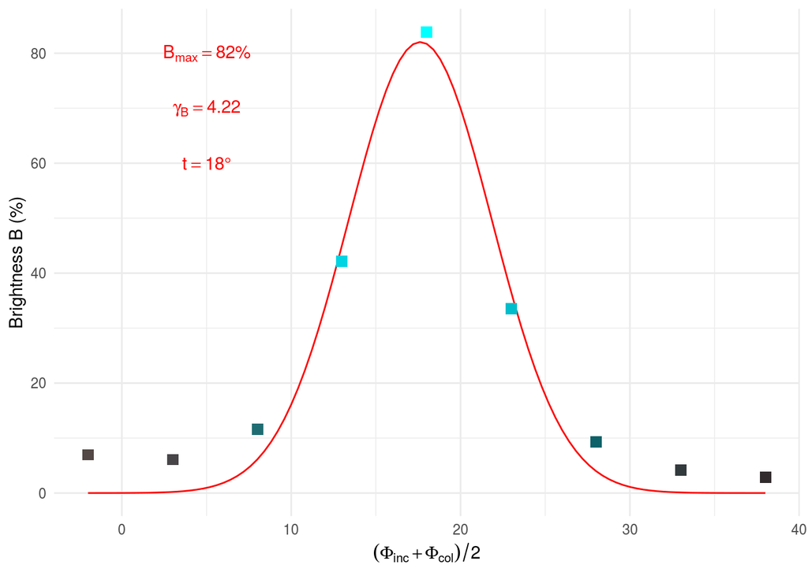

```r
ggplot(helfur_br_bvar, aes(x = normale, y = B2, col = factor(normale))) +
  stat_function(fun = fnorm, args = helfur_br_bregres, color = "red") +
  geom_point(shape = "square", size = 3) +
  xlab(expression((Phi[inc]+Phi[col])/2)) +
  ylim(c(0, max(helfur_br_bvar$B2, helfur_br_hvar$B2))) +
  ylab("Brightness B (%)") +
  scale_color_manual(values = unname(spec2rgb(helfur_br_b))) +
  theme(legend.position = "none") +
  annotate("text", x = 5, y = 80, color = "red",
           label = sprintf("B[max]== %.0f*'%%'", helfur_br_bregres[["Bmax"]]), parse = TRUE) +
  annotate("text", x = 5, y = 70, color = "red",
           label = sprintf("gamma[B]== %.2f", helfur_br_bregres[["gammaB"]]), parse = TRUE) +
  annotate("text", x = 5, y = 60, color = "red",
           label = sprintf("t== %.0f*'°'", helfur_br_bregres[["t"]]), parse = TRUE)
```

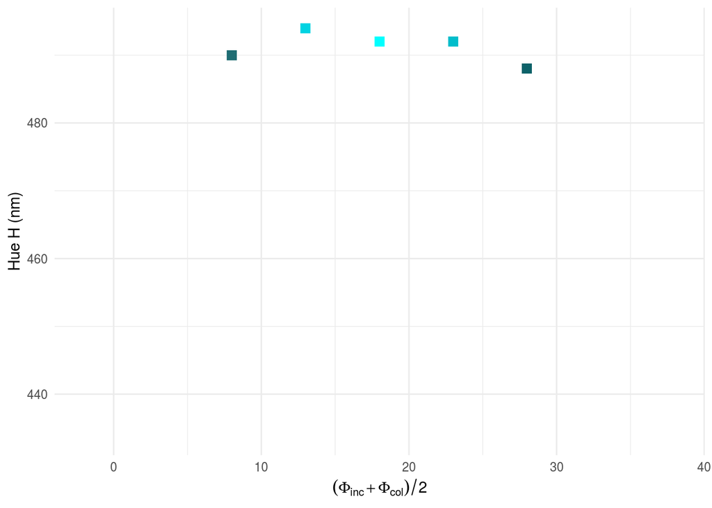

```r
ggplot(helfur_br_bvar, aes(x = normale, y = H1, col = factor(normale))) +
  geom_point(shape = "square", size = 3) +
  xlab(expression((Phi[inc]+Phi[col])/2)) +
  ylim(range(helfur_br_bvar$H1, helfur_br_hvar$H1, na.rm = TRUE)) +
  ylab("Hue H (nm)") +
  scale_color_manual(values = unname(spec2rgb(helfur_br_b))) +
  theme(legend.position = "none")
```

# Session info

[session information not shown]

```
 setting  value
 version  R version 3.5.1 (2018-07-02)
 system   x86_64, linux-gnu
 ui       RStudio (1.1.423)
 language en_US
 collate  en_US.UTF-8
 tz       Europe/Paris
 date     2018-09-04

 package     * version date       source
 abind         1.4-5   2016-07-21 CRAN (R 3.5.0)
 assertthat    0.2.0   2017-04-11 CRAN (R 3.5.0)
 backports     1.1.2   2017-12-13 CRAN (R 3.5.0)
 base        * 3.5.1   2018-07-03 local
 base64enc     0.1-3   2015-07-28 CRAN (R 3.5.0)
 bindr         0.1.1   2018-03-13 CRAN (R 3.5.0)
 bindrcpp    * 0.2.2   2018-03-29 CRAN (R 3.5.0)
 bmp           0.3     2017-09-11 cran (@0.3)
 broom         0.5.0   2018-07-17 CRAN (R 3.5.1)
 Cairo         1.5-9   2015-09-26 CRAN (R 3.5.1)
 cellranger    1.1.0   2016-07-27 CRAN (R 3.5.0)
 cli           1.0.0   2017-11-05 CRAN (R 3.5.0)
 codetools     0.2-15  2016-10-05 CRAN (R 3.5.0)
 colorspace    1.3-2   2016-12-14 CRAN (R 3.5.0)
 compiler      3.5.1   2018-07-03 local
 crayon        1.3.4   2017-09-16 CRAN (R 3.5.0)
 datasets    * 3.5.1   2018-07-03 local
 devtools      1.13.6  2018-06-27 CRAN (R 3.5.1)
 digest        0.6.15  2018-01-28 CRAN (R 3.5.0)
 dplyr       * 0.7.6   2018-06-29 cran (@0.7.6)
 evaluate      0.11    2018-07-17 cran (@0.11)
 forcats     * 0.3.0   2018-02-19 CRAN (R 3.5.0)
 future        1.9.0   2018-07-23 CRAN (R 3.5.1)
 geometry      0.4.0   2018-06-19 Github (davidcsterratt/geometry@d5c98e7)
 ggplot2     * 3.0.0   2018-07-03 CRAN (R 3.5.1)
 ggrastr     * 0.1.5   2018-08-14 Github (VPetukhov/ggrastr@82aa62b)
 globals       0.12.1  2018-06-25 CRAN (R 3.5.1)
 glue          1.3.0   2018-07-17 cran (@1.3.0)
 graphics    * 3.5.1   2018-07-03 local
 grDevices   * 3.5.1   2018-07-03 local
```

[output cut: 49 more lines]

```
 sp            1.3-1   2018-06-05 cran (@1.3-1)
 stats       * 3.5.1   2018-07-03 local
 stringi       1.2.4   2018-07-20 cran (@1.2.4)
 stringr     * 1.3.1   2018-05-10 CRAN (R 3.5.0)
 tibble      * 1.4.2   2018-01-22 CRAN (R 3.5.0)
 tidyr       * 0.8.1   2018-05-18 CRAN (R 3.5.0)
 tidyselect    0.2.4   2018-02-26 CRAN (R 3.5.0)
 tidyverse   * 1.2.1   2017-11-14 CRAN (R 3.5.0)
 tiff          0.1-5   2013-09-04 cran (@0.1-5)
 tools         3.5.1   2018-07-03 local
 utils       * 3.5.1   2018-07-03 local
 viridisLite   0.3.0   2018-02-01 CRAN (R 3.5.0)
 withr         2.1.2   2018-03-15 CRAN (R 3.5.0)
 xml2          1.2.0   2018-01-24 CRAN (R 3.5.0)
 yaml          2.2.0   2018-07-25 cran (@2.2.0)
```